# PEC 1 - Anàlisi de dades Òmiques

Alejandro Sendín Emiliano

2026-03-31

# Exercici 1. Exploració multivariant d’un dataset de metabolòmica

## Introducció i objectius

Es proporcionen tres conjunts de dades provinents de metabolòmica: “assay.csv”, “sample_metadata.csv” i “feature_metadata.csv”. El primer és una matriu d’intensitats amb metabòlits i mostres, el segon arxiu conté informació fenotípica i tècnica de les mostres i, el tercer, inclou informació més detallada de cada metabòlit.

Aquestes dades de forma aïllada és difícil visualitzar-les i analitzar-les. Amb l’ajuda de Bioconductor, es pretén elaborar un objecte que contingui tota aquesta informació. Com amb qualsevol conjunt de dades, será necessari realitzar un pre-processat d’aquesta informació. Aquest procés va lligat al de la reducció de la dimensionalitat de les dades, el qual es realitzará seguint el métode d’anàlisi de components principals (PCA).

Tot i que l’anàlisi per PCA sigui molt útil i popular, a l’última part de l’exercici es valoraran altres tècniques de reducció de dades.

Per tant, els objectius d’aquest exercici es poden resumir en:

> - Construir un contenidor adequat amb les dades proporcionades
> - Crear un subconjunt de treball
> - Preparar les dades per al seu anàlisi
> - Realitzar un anàlisi PCA
> - Comparar altres mètodes de reducció de la dimensió

## Mètodes

### Construcció del contenidor i selecció de mostres

Es visualitzen els conjunts de dades proporcionats:

Primers 6 registres d’assay

|  | S039 | S022 | S044 | S043 | S020 | S041 | S010 | S047 | S003 | S048 | S055 | S006 | S053 | S023 | S059 | S009 | S060 | S027 | S052 | S015 | S042 | S040 | S031 | S032 | S024 | S036 | S016 | S001 | S030 | … |
| --- | --- | --- | --- | --- | --- | --- | --- | --- | --- | --- | --- | --- | --- | --- | --- | --- | --- | --- | --- | --- | --- | --- | --- | --- | --- | --- | --- | --- | --- | --- |
| M001 | 490.2864 | 7165.688 | 545.5053 | 447.6373 | 4348.183 | 432.6250 | 517.0648 | 5000.152 | NA | 5443.299 | 6534.722 | 349.8794 | 5155.328 | 5150.090 | 4971.163 | 542.9684 | 4468.439 | 5472.606 | 3818.908 | 414.7959 | 394.3604 | 588.6825 | 487.9110 | 498.9714 | 5440.069 | 381.5599 | 6618.481 | 415.8650 | 6363.685 | … |
| M002 | 665.2812 | NA | 457.5020 | 556.2519 | 5233.424 | 503.4044 | 361.8541 | 4823.131 | 426.5072 | 6050.300 | 5293.103 | 403.8999 | 6738.942 | 5657.134 | 5382.067 | 448.6064 | 5669.482 | 6085.134 | 5857.796 | 327.1494 | 360.9874 | 551.5358 | 482.5631 | 295.6898 | 4386.205 | 430.0545 | 6543.844 | 542.9291 | 5858.767 | … |
| M003 | 401.9697 | 4484.074 | 475.8505 | 432.8816 | 4025.300 | 311.1022 | 366.6884 | 3283.193 | 372.2119 | 5888.650 | 3822.672 | 245.6366 | 5038.733 | 4244.659 | 4308.564 | 355.7689 | 4994.289 | 2691.430 | 3855.155 | 331.0530 | 391.3247 | 337.6635 | 331.6565 | 449.9940 | 3595.156 | 379.6526 | 5019.258 | 335.3027 | 4600.594 | … |
| M004 | 1021.5338 | 7579.311 | 737.1133 | 680.2842 | 6955.674 | 798.1026 | 703.1891 | 9991.180 | 900.5957 | 10313.814 | 8258.397 | 513.5389 | 9347.964 | 9191.456 | 8639.532 | 689.9662 | 8094.441 | 8845.705 | 13079.475 | 638.5563 | 767.1463 | 862.8999 | 670.1338 | 776.2769 | 8128.413 | 1031.4629 | NA | 696.0731 | 8418.383 | … |
| M005 | 597.1458 | NA | 513.5203 | 1035.6678 | 5474.864 | 584.0704 | 729.1660 | NA | 759.6935 | 10135.810 | 6489.356 | 555.8808 | 8603.861 | 6346.378 | 6342.114 | 736.3735 | 5637.142 | 6551.957 | NA | 462.9170 | 585.3525 | 709.9628 | 668.8781 | 640.4494 | 6277.745 | 587.6336 | NA | 490.8305 | 7066.382 | … |
| M006 | 411.2816 | 8443.677 | 401.1540 | 523.2028 | 6313.708 | NA | NA | 7007.193 | 297.0628 | 5511.586 | 7189.674 | 209.9463 | 7465.394 | 5173.795 | 6186.251 | 333.9063 | 5096.574 | 5566.247 | 8518.018 | 323.7640 | 330.9256 | 417.1871 | 489.8903 | 349.9927 | 5228.896 | 460.0502 | 7872.048 | 358.4005 | NA | … |

Tal i com es veu a la taula, assay conté els metabòlits a les files i les columnes corresponen a les diferents mostres. També es possible veure que tenim valors NA. Posteriorment es gestionaran.

Primers 6 registres de sample_metadata

|  | group | batch | sex | age | bmi | cholesterol |
| --- | --- | --- | --- | --- | --- | --- |
| S039 | Case | Batch1 | M | 44 | 27.4 | 222.6 |
| S022 | Control | Batch2 | F | 47 | 21.0 | 157.7 |
| S044 | Case | Batch1 | F | 52 | 28.2 | 206.8 |
| S043 | Case | Batch1 | M | 58 | 28.5 | 212.7 |
| S020 | Control | Batch2 | M | 52 | 22.0 | 168.4 |
| S041 | Case | Batch1 | F | 45 | 27.4 | 236.8 |

Sample_metadata conté tantes files com mostres i les columnes són: group, batch, sex, age, bmi i cholesterol. És a dir, en aquest dataset cada mostra es troba contextualitzada per 6 variables diferents.

Primers 6 registres de feature_metadata

|  | metabolite_name | class | platform |
| --- | --- | --- | --- |
| M001 | Metab_batch_01 | Amino acid | LC-MS positive |
| M002 | Metab_batch_02 | Acylcarnitine | LC-MS negative |
| M003 | Metab_batch_03 | Bile acid | GC-MS |
| M004 | Metab_batch_04 | Fatty acid | LC-MS positive |
| M005 | Metab_batch_05 | Lipid | LC-MS negative |
| M006 | Metab_batch_06 | Organic acid | GC-MS |

Finalment el dataset feature_metadata integra els diferents metabòlits a les files i les columnes són les variables que els defineixen, en aquest cas: metabolite_name, class i platform.

Veient els tipus de dades que tenim, sembla natural fer servir el tipus de contenidor **SummarizedExperiment** provinent de Bioconductor. Aquest paquet ofereix un contenidor que allotja els aspectes essencials dels experiments individuals en un únic objecte que coordina les dades i les metadades durant les operacions de subconjunt i reordenació. SummarizedExperiment és un contenidor semblant a una matriu on les **files representen característiques d’interès** (per exemple, gens, transcrits, exons, etc.) i les **columnes representen mostres** (The Carpentries Incubator 2025).

Per crear l’objecte **SummarizedExperiment** fem servir el codi següent:

```r
se <- SummarizedExperiment(
  assays = list(counts = assay_data), # df assay com a matriu principal
  colData = sample_metadata, # info de les mostres
  rowData = feature_metadata # info dels metabòlits
)
se
```

```
## class: SummarizedExperiment
## dim: 120 60
## metadata(0):
## assays(1): counts
## rownames(120): M001 M002 ... M119 M120
## rowData names(3): metabolite_name class platform
## colnames(60): S039 S022 ... S017 S026
## colData names(6): group batch ... bmi cholesterol
```

En principi sembla que encaixa amb les taules dels diferents dataframes descrits anteriorment.

Comprovem que les dades estiguin correctament alineades:

```r
nrow(assay(se)) == nrow(rowData(se)) # el nº de files a la matriu de dades ha de
```

```
## [1] TRUE
```

```r
# ser igual que el número de files de feature_metadata
ncol(assay(se)) == nrow(colData(se)) # el nº de columnes a la matriu de dades ha
```

```
## [1] TRUE
```

```r
#de ser igual que el número de files de sample_metadata
```

També comprovem que els noms coincideixin:

```r
all(rownames(se) == rownames(rowData(se))) # els noms de les files a la matriu
```

```
## [1] TRUE
```

```r
# de dades equivalen als els de feature_metadata
all(colnames(se) == rownames(colData(se))) # els noms de les columnes a la
```

```
## [1] TRUE
```

```r
# matriu de dades equivalen als els de les files de sample_metadata
```

Finalment es fa una ullada general a les diferents entrades de se:

|  | S039 | S022 | S044 | S043 | S020 |
| --- | --- | --- | --- | --- | --- |
| M001 | 490.2864 | 7165.688 | 545.5053 | 447.6373 | 4348.183 |
| M002 | 665.2812 | NA | 457.5020 | 556.2519 | 5233.424 |
| M003 | 401.9697 | 4484.074 | 475.8505 | 432.8816 | 4025.300 |
| M004 | 1021.5338 | 7579.311 | 737.1133 | 680.2842 | 6955.674 |
| M005 | 597.1458 | NA | 513.5203 | 1035.6678 | 5474.864 |

```
## DataFrame with 6 rows and 3 columns
##      metabolite_name         class       platform
##          <character>   <character>    <character>
## M001  Metab_batch_01    Amino acid LC-MS positive
## M002  Metab_batch_02 Acylcarnitine LC-MS negative
## M003  Metab_batch_03     Bile acid          GC-MS
## M004  Metab_batch_04    Fatty acid LC-MS positive
## M005  Metab_batch_05         Lipid LC-MS negative
## M006  Metab_batch_06  Organic acid          GC-MS
```

```
## DataFrame with 6 rows and 6 columns
##            group       batch         sex       age       bmi cholesterol
##      <character> <character> <character> <integer> <numeric>   <numeric>
## S039        Case      Batch1           M        44      27.4       222.6
## S022     Control      Batch2           F        47      21.0       157.7
## S044        Case      Batch1           F        52      28.2       206.8
## S043        Case      Batch1           M        58      28.5       212.7
## S020     Control      Batch2           M        52      22.0       168.4
## S041        Case      Batch1           F        45      27.4       236.8
```

Es crea un subconjunt de 50 mostres que contenen casos i controls a parts iguals anomenat “se_sub”. Aquest serà l’objecte de l’anàlisi per PCA.

```r
se_sub
```

```
## class: SummarizedExperiment
## dim: 120 50
## metadata(0):
## assays(1): counts
## rownames(120): M001 M002 ... M119 M120
## rowData names(3): metabolite_name class platform
## colnames(50): S043 S044 ... S030 S052
## colData names(6): group batch ... bmi cholesterol
```

```r
table(colData(se_sub)$group)
```

```
##
##    Case Control
##      25      25
```

Per fer aquest subconjunt, primer s’han guardat els noms de les mostres que corresponen al grup “Cases” a una variable i les que corresponen al grup “Control” en una altra, obtenint dos vectors amb els noms de les mostres per cada grup. Si s’examinen aquests vectors es pot veure com cadascun conté 30 elements, de manera que en total son 60 registres que de base ja estan dividits de forma equitativa.

Es determina la llavor per randomitzar, que en aquest cas és la 223, i s’escullen 25 mostres de cada llistat aleatòriament. S’uneixen les dues mostres de 25 de cada grup i es tornen a mesclar. Per acabar, a partir de l’objecte original se, s’agafen tots els registres corresponents als noms de les mostres que hem seleccionat i es configura un nou objecte se_sub amb 50 mostres dividides equitativament entre els dos grups.

Les mostres seleccionades són:

```
##  [1] "S043" "S044" "S018" "S001" "S009" "S022" "S050" "S047" "S028" "S042"
## [11] "S008" "S051" "S026" "S059" "S011" "S058" "S033" "S055" "S037" "S006"
## [21] "S048" "S023" "S003" "S005" "S010" "S056" "S017" "S002" "S039" "S021"
## [31] "S049" "S041" "S016" "S034" "S013" "S029" "S038" "S032" "S031" "S054"
## [41] "S025" "S014" "S020" "S045" "S027" "S015" "S057" "S040" "S030" "S052"
```

### Preparació de les dades

Abans de fer l’anàlisi per PCA, cal fer una sèrie de comprovacions i modificacions al subconjunt d’estudi per poder treballar amb ell.

S’ha vist que hi ha valors perduts, per tant el primer pas serà tractar-los, tenint en compte que si un metabolit supera el 20% de valors faltants s’eliminarà del dataset i, en canvi, si el percentatge és inferior al 20% es mantindrà en el dataset i s’imputen els valors mitjançant un algoritme com KNN.

Seguidament es realitzarà una escalada de les dades. Aquest procés gairebé sempre s’ha de fer abans d’un anàlisi de components principals. En aquest cas passant la vista pels petits resums anteriors es pot veure com les dades varien força segons la mostra o metabòlit.

El penúltim aspecte a determinar és si cal o no transformar les dades. Per veure-ho, es generaran i revisaran gràfics per veure asimetries.

Finalment, es determinarà si hi ha outliers o valors que s’allunyen en excés de la tendència general.

Tot aquest procés es pot fer seguint el workflow de referència del paquet POMA (Castellano-Escuder et al. 2021)

Abans però es realitza un canvi en la naturalesa de la variable “group” que al passar-la a factor ajudarà a la comprensió dels gràfics.

```r
colData(se_sub)$group <- factor(colData(se_sub)$group)
```

Ara continuem amb la primera fita, fer la retirada i/o imputació dels valors NA:

```r
se_imp <- PomaImpute(se_sub, method = "knn", zeros_as_na = TRUE,
                     remove_na = TRUE, cutoff = 20)
```

```
## 0 features removed.
```

Es pot veure com no s’ha retirat cap valor. A continuació es normalitzen les dades.

```r
se_norm <- PomaNorm(se_imp, method = "log_pareto")
```

Degut a que no es possible representar “features” amb el gràfic PomaDensity es fa servir “samples” per visualitzar el guany de normalitzar les dades.

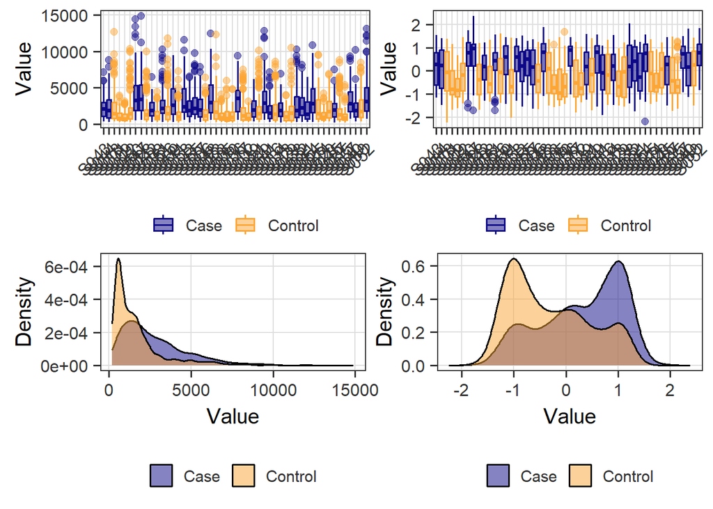

Efecte de la normalització de dades

L’escalat de les dades ha funcionat força bé tal i com es veu en els gràfics. No es valora per tant transformar les dades.

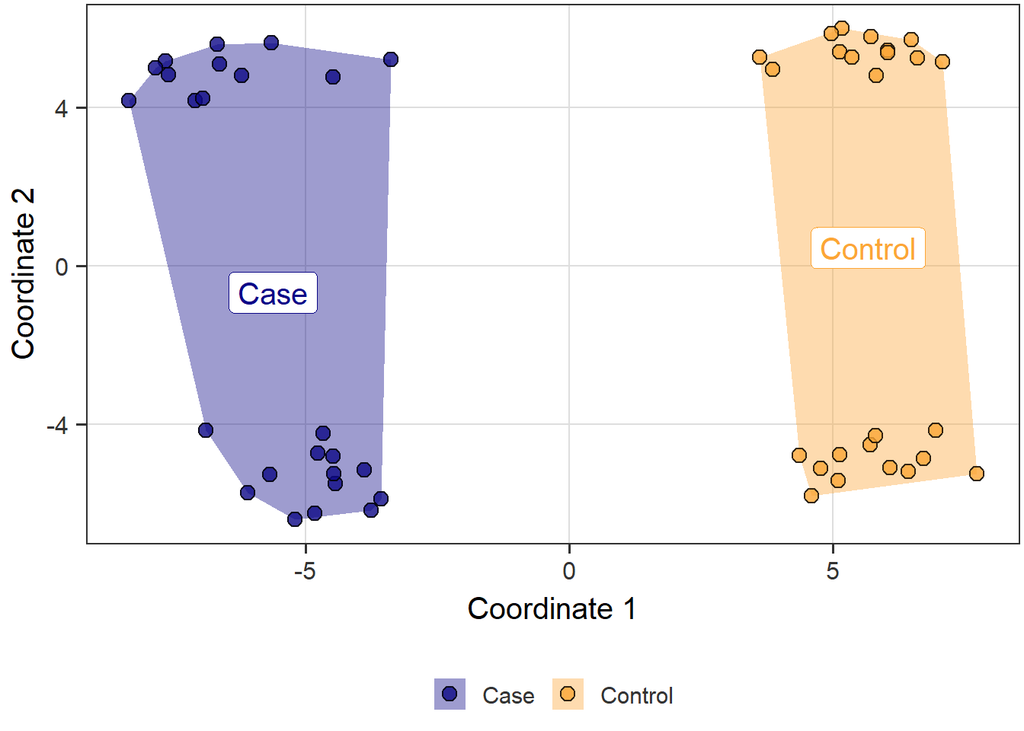

Gràfic de visualització d’outliers

Tampoc es veuen outliers clars, tots els punts es troben relacionats. Es destaca una clara diferència entre casos i controls i, en cadascun d’ells, hi ha una divisió dels punts en dues bandes superior i inferior clarament diferenciada. Per aquest motiu, es revisa que no hi hagi efecte batch en les dades. Per fer-ho fàcil, es col·loca la columna “batch” la primera a colData i es modifica el seu tipus de variable a factor, de manera que el gràfic de POMA agafi la columna “batch” com la referència per fer el gràfic i així veure si hi ha diferències:

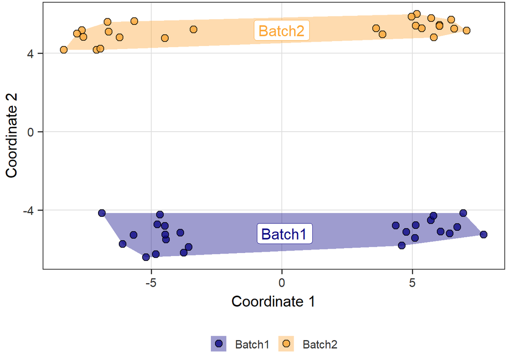

Gràfic de visualització de l’efecte batch

Clarament l’efecte batch té un gran impacte en les dades, les divideix en dos grups totalment separats. De fet, fent una taula de freqüències de SummarizedExperiment original obtenim una divisió perfecta entre casos i controls i batch1 i batch2.

```r
table(colData(se)$batch, colData(se)$group)
```

```
##
##          Case Control
##   Batch1   15      15
##   Batch2   15      15
```

Repetim la taula pel subconjunt d’estudi i es comprova que la dinàmica és igual.

```r
table(colData(se_norm)$batch, colData(se_norm)$group)
```

```
##
##          Case Control
##   Batch1   13      12
##   Batch2   12      13
```

Per fortuna, un element de “batch” no s’associa exclusivament o en gran part a un element sol de “group”, ja que llavors serien la mateixa variable.

Ara per corregir l’efecte batch es fa servir la funció “removeBatchEffect”.

```r
se_nobatch <- removeBatchEffect(mat, batch = batch, design = design)

assay(se_norm, "nobatch") <- se_nobatch
```

Ara s’introdueix una nova variable, se_tmp, que sigui igual que se_norm però amb les dades tractades per eliminar el batch:

```r
se_tmp <- se_norm
assay(se_tmp) <- assay(se_norm, "nobatch")
```

Es realitza de nou el gràfic d’outliers per visualitzar que s’ha eliminat l’efecte batch:

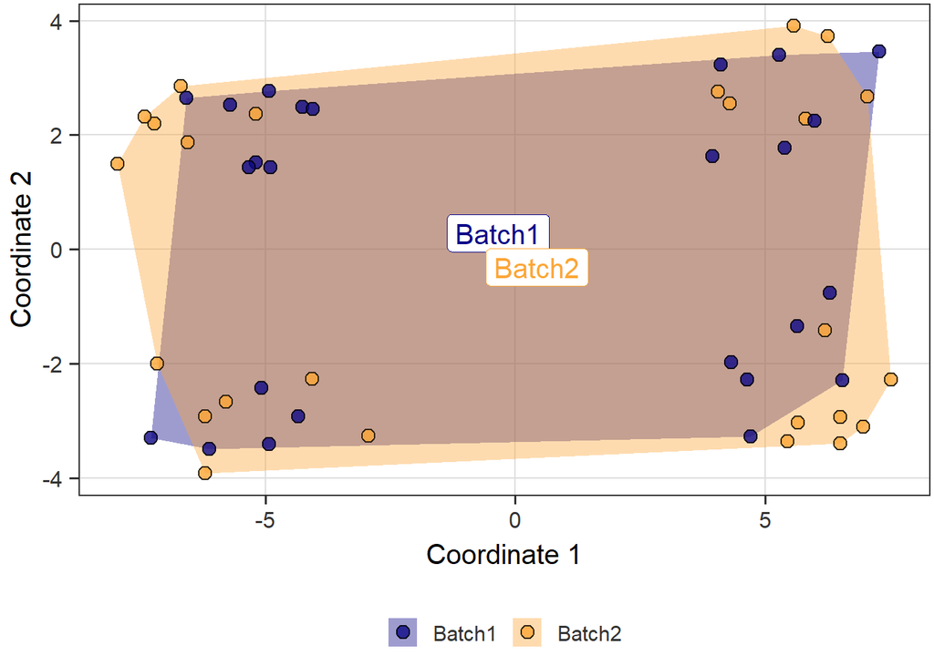

Gràfic de visualització: efecte batch eliminat

En quant a la variable batch sembla que s’ha corregit l’efecte. Es retornen les columnes group i batch al seu lloc i es torna a repetir el gràfic amb la variable group.

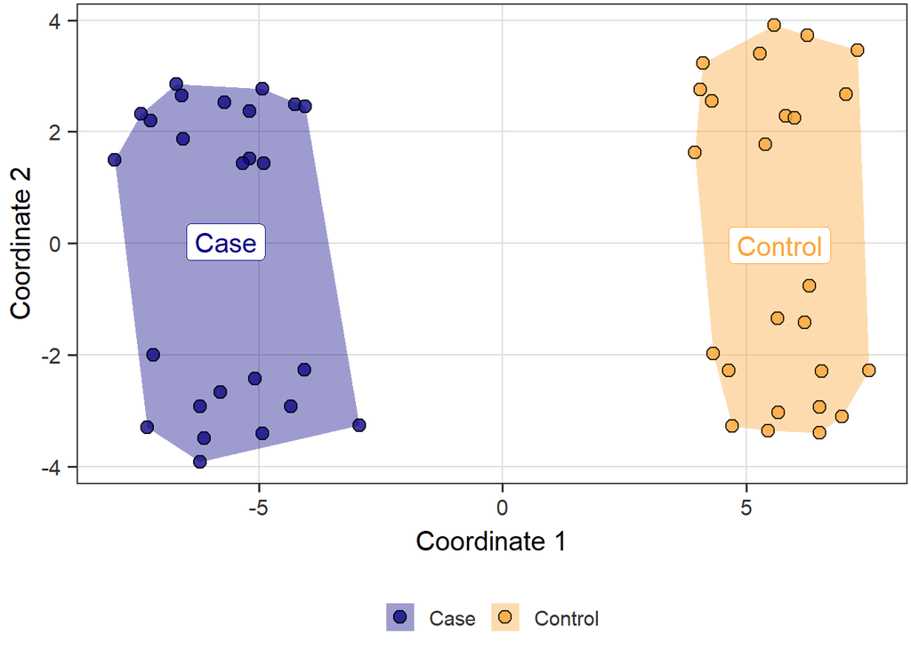

Gràfic de visualització: grups correctament separats

Efectivament, s’ha conservat la divisió per casos i controls mentre que s’ha eliminat l’efecte batch.

De manera que el subconjunt d’estudi per fer l’anàlisi de PCA serà **se_tmp**.

## Resultats

### Anàlisi mitjançant PCA

L’anàlisi de PCA es por fer mitjançant **PomaPCA** de nou de forma fàcil.

S’obtenen els valors de variança explicada per cada component:

```r
pca$eigenvalues
```

| comp | var_exp |
| --- | --- |
| PC1 | 73.758542 |
| PC2 | 15.585617 |
| PC3 | 8.048921 |
| PC4 | 2.606921 |

S’obté un percentatge de variança explicada del 73,76% només amb la primera component. La suma de la primera i la segona component explicarien gairebé el 90% del total de la variança.

Representem gráficament les dues primeres components:

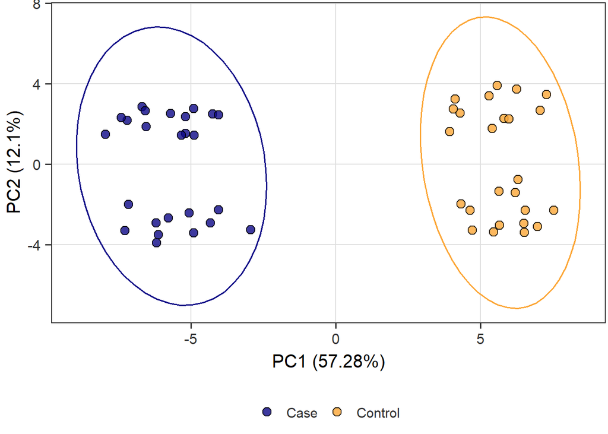

Gràfic de representació de PC1 i PC2

Es pot veure una distribució igual que la descrita amb el gràfic dels outliers. La variable “group” comporta un 57,28% de la variabilitat en la primera component, cosa que determina en gran part l’estructura gràfica obtinguda. La segona component separa les variables en subgrups. Per saber quina variable està separant en aquests subgrups, el més ràpid és crear un PCA normal amb la funció prcomp() i graficar amb colors segons la variable amb un bucle:

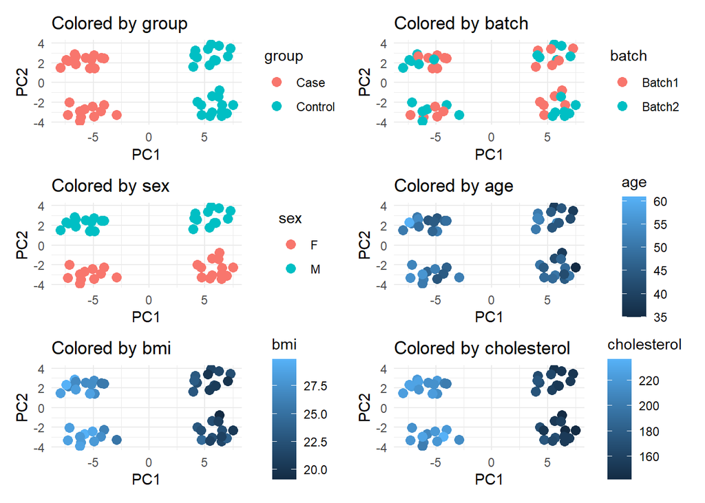

Visualització per color de les variables

Es pot veure com la variable responsable de dividir les dades a nivell vertical és “sex”, generant un 12,1% de variabilitat en la segona component. Altres variables com “bmi” o “cholesterol” tenen els seus valors també molt dividits a nivell horitzontal, és a dir, els controls aparentment tenen valors de bmi i colesterol més baixos.

També es podrien obtenir els “loadings” o contribucions de cada metabòlit a cada component o, fins i tot, representar un “scree plot”:

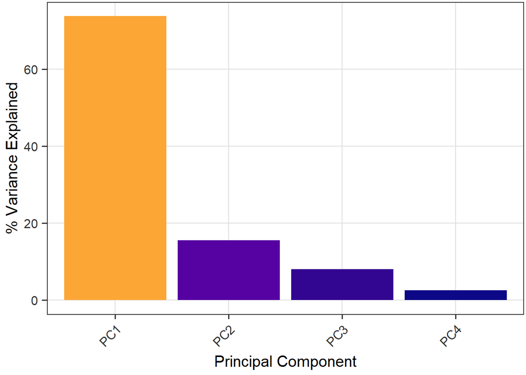

Scree plot

Degut als resultats s’agafa la primera i segona component per descriure el total de les dades, ja que conjuntament explicarien un 89,3% de la variabilitat.

Si analitzem els “loadings”, es pot obtenir un llistat de les variables (metabòlits) amb un component més gran (més contribució) en la primera component.

```r
loads <- pca$loadings
var_loads <- loads[order(abs(loads$PC1), decreasing = TRUE), ]
head(var_loads[,1:2], 5)
```

| feature | PC1 |
| --- | --- |
| M035 | -0.1899315 |
| M025 | -0.1886038 |
| M043 | -0.1879315 |
| M036 | -0.1876776 |
| M038 | -0.1867917 |

### Comparació amb altres mètodes

Es fa servir **UMAP** com a mètode alternatiu per reduir la dimensió de les dades del subconjunt **se_tmp**. Per fer-ho, s’utilitza la funció **umap** sobre la matriu de dades de l’assaig, obtenint un component nou anomenat “layout” que conté les coordenades per poder visualitzar les dades obtingudes.

Es realiza doncs una execució de la funció umap sobre X (matriu d’assaig definida de se_tmp), es crea un dataframe amb les dades de layout i de la variable de colData “group” i es visualitza a través d’un gràfic de ggplot2.

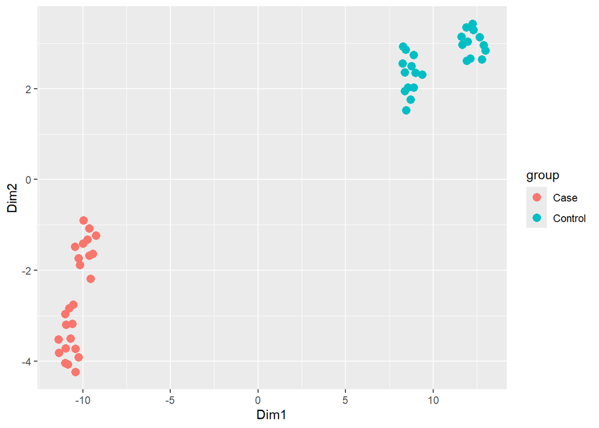

UMAP: Coordenades segons la variable group

UMAP agrupa aquells punts que considera més propers aplicant k-nn, que per defecte serà k = 2. S’observen estructures similars a les obtingudes mitjançant l’anàlisi per PCA. Si més no, en aquest cas és útil per veure la distància que hi ha entre les dades, en especial la que es genera entre els casos i controls. En aquest cas també s’observa certa distància no només a nivell horitzontal si no també verticalment entre els dos grups. Aquesta distància podria ser la reflectida per la variable sexe, que amb un percentatge més baix influia la segona component a nivell vertical.

Per tant, PCA i UMAP tot i tenir semblances en la funcionalitat, ambdós generen uns outputs que poden interpretar-se de formes diferents i/o obtenir conclusions variables. La idea és poder combinar les dues tècniques per poder tenir una visió ampliada de les dades i descobrir patrons desapercebuts.

## Interpretació global de l’anàlisi, discussió

Les dades, un cop escalades, prenen una posició gràfica molt evident, és a dir, es distribueixen clarament per grups segons si són “casos” o “control” i, dins d’aquests grups, trobem subgrups formats probablement per l’acció d’altres paràmetres biològics com el sexe. També, amb l’efecte batch es podia apreciar una diferència total entre les dades clasificades com a batch1 i les que eren batch2. Finalment amb UMAP es pot visualitzar una més clara presentació de les dades i els subgrups, en les que les caracteritzades com a “casos” es presenten al quadrant inferior esquerre del gràfic mentre que les dades “control” prenen posició al quadrant superior dret.

La classificació en casos o controls determina totalment la disposició de les dades, de fet, segons el gràfic de factors fet amb PomaPCA, la primera component separa en casos o controls amb un 57,3%. Si més no, a la segona component hem vist que la variable “sex” explica un 12,1% de variabilitat i divideix les dades a nivell vertical. Altres variables com el bmi o el colesterol tenen els seus valors màxims amb les mostres situades com a casos i els inferiors als controls. Això últim és important ja que podria ser doncs que les 3 variables (“group,”bmi” i “cholesterol”) patissin certa colinealitat per representar de la mateixa manera les dades.

Al tractar-se d’un conjunt de dades contingut en un objecte de tipus S4 SummarizedExperiment, el seu anàlisi sembla més complex que el que es plantejaria amb un dataset qualsevol. Podria ser que no s’hagi interpretat bé els resultats obtinguts o que fins i tot la metodologia no sigui la correcta. El fet de tenir efecte batch ha generat també un tractament de les dades que podria no ser l’adequat. Per altra banda, els mètodes alternatius de reducció de la dimensió són totalment desconeguts i tampoc queda ben bé clar si s’han executat o interpretat bé.

Degut al tipus de dades i la seva estructura, es podria plantejar un anàlisi de la linealitat, veure quines dades de colData realment són útils conservar.

# Exercici 2. Revisió d’un article

L’article a revisar és “Large-Scale Multi-omic Analysis of COVID-19 Severity” (Overmyer et al. 2021).

La hipòtesi d’aquest estudi és que la mesura d’un gran nombre de biomolècules de diverses classes diferents (àcids nucleics, proteïnes, lípids i metabòlits) proporciona informació sobre l’horitzó molecular en el que se situa la COVID-19 i facilitaria els coneixements per entendre els factors associats a una major severitat.

Per donar resposta a aquesta hipòtesi, es recullen principalment 2 tipus de dades en un total de 102 pacients amb COVID-19 i 26 pacients sense la malaltia. Per una banda s’obté informació clínica rellevant (demogràfica i característiques generals del perfil dels pacients) i per una altra, la més important, s’extreuen mostres de sang per obtenir valors quantitatius de totes les dades òmiques: transcrits leucocitaris, proteïnes plasmàtiques, lípids i molècules petites transformades a log2. Tot i ser repertoris de dades diferents, el que ens diuen és que les dades demogràfiques ajuden a contextualitzar les dades òmiques recollides. També és interessant el fet que aprofiten aquestes mostres de sang de les dades òmiques per verificar que les dades clíniques encaixen amb les descrites.

En total, es determinen més de 17000 biomolècules diferents i es crea una base de dades relacionals SQLite lliure juntament amb una app que explora les dades de forma més interactiva.

A partir d’aquí utilitzen els pacients que tenen totes les dades de biomolècules completes (n = 125). Transformen aquestes dades amb log2() i les escalen. Seguidament fan servir la funció prcomp() per realitzar l’anàlisi PCA. El resultat de l’anàlisi es veu en la següent imatge:

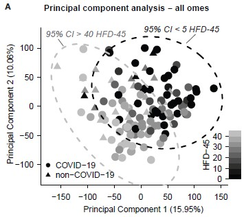

Gràfic de les 2 primeres components de l’article

En conjunts de dades tan amplis, el fet de realitzar un anàlisi PCA i reduir la dimensió a un terreny més bàsic, pot revelar patrons que aparentment no eren apreciables desde un començament i orientar l’anàlisi amb més sentit. En aquest cas el que ens diuen és que el motiu de fer PCA recau en intentar obtenir una resposta a la seva hipòtesi de forma no supervisada, és a dir, se sobreentén que posteriorment realitzaran un anàlisi supervisat més específic.

Pels resultats del gràfic, es veu una primera component en la que sembla que la divisió de pacients en un baix HFD-45 (alta severitat) i alt HFD-45 (baixa severitat) comporta la principal font de variabilitat en les dades. Aquesta divisió s’efectua diagonalment creant un patró més o menys lineal, de manera que la segona component també està afectada, segurament en menor nivell, a la variabilitat de les dades pel grau de severitat. Els autors es limiten a evidenciar la forma que prenen les dades al gràfic i indiquen també el valors de la variabilitat capturada pels components 1 i 2, en aquest cas un 16% i un 10% respectivament. A més a més també defineixen un lleuger agrupament de les dades segons si tenen o no la malaltia. Consideren que aquests patrons són suficient raó per a dur a terme una posterior exploració supervisada (regressió) sobre l’estatus COVID-19 (si o no) i el valor d’HFD-45.

Per concluir, fent un anàlisi de PCA ha permès manifestar una tendència específica de les dades segons el seu grau de severitat. La consulta també ofereix els percentatges de variabilitat extreta per cada component i evidencia altres petits matissos, com l’agrupament segons si els pacients tenen o no COVID-19. Tot això és útil no tant com per reduir el conjunt de dades a només 2 components, ja que es perdria massa informació (només s’obté una variabilitat explicada d’un 26% amb PC1 i 2), si no per obtenir una idea ràpida de cap a on poden apuntar les dades i cap a on es podria dirigir l’estudi. Si més no, si que em resulta evident que la mostra de pacients que no presenten la malaltia és baixa comparada amb els que si la tenen.

# Apèndix: codi R utilitzat

```r
# input per SummarizedExperiment
# s'obté cada conjunt de dades per separat
assay_data <- read.csv("assay.csv", row.names = 1)
sample_metadata <- read.csv("sample_metadata.csv", row.names = 1)
feature_metadata <- read.csv("feature_metadata.csv", row.names = 1)

# taula del df assaig
kable(head(assay_data), caption = "Primers 6 registres d'assay")

# taula del df mostres
kable(head(sample_metadata), caption = "Primers 6 registres de sample_metadata")

# taula del df de feature
kable(head(feature_metadata), caption = "Primers 6 registres de feature_metadata")

#construcció i visualització de l'objecte SE
se <- SummarizedExperiment(
  assays = list(counts = assay_data), # df assay com a matriu principal
  colData = sample_metadata, # info de les mostres
  rowData = feature_metadata # info dels metabòlits
)
se

# comprovacions de igual nº files/col
nrow(assay(se)) == nrow(rowData(se)) # el nº de files a la matriu de dades ha de
# ser igual que el número de files de feature_metadata
ncol(assay(se)) == nrow(colData(se)) # el nº de columnes a la matriu de dades ha
#de ser igual que el número de files de sample_metadata

# comprovació de noms iguals entre diferents entrades del SE
all(rownames(se) == rownames(rowData(se))) # els noms de les files a la matriu
# de dades equivalen als els de feature_metadata
all(colnames(se) == rownames(colData(se))) # els noms de les columnes a la
# matriu de dades equivalen als els de les files de sample_metadata

# visualització dades del SE
assay(se)[1:5, 1:5]
head(rowData(se))
head(colData(se))

# s'obtenen les mostres de 25 casos i 25 controls
# primer es guarden els noms de les mostres corresponents a "Case"
casos <- colnames(se)[colData(se)$group == "Case"]
# i es guarden en una altra variable els noms de mostres caracteritzades pel grup "Control"
controls <- colnames(se)[colData(se)$group == "Control"]

set.seed(223) # s'indica la llavor per fer la random
# s'escullen 25 mostres random de casos
sel_casos <- sample(casos, 25)
# s'escullen 25 mostres random de controls
sel_controls <- sample(controls, 25)
# genera les mostres i les mescla de nou
sel_samples <- sample(c(sel_casos, sel_controls))
# finalment es crea el subset a partir de SE, incorporant les columnes random
se_sub <- se[, sel_samples]

table(colData(se_sub)$group) # es comprova que s'ha fet la partició correctament

sel_samples

# canvi tipus variable group a factor
colData(se_sub)$group <- factor(colData(se_sub)$group)

# retirada valors NA
se_imp <- PomaImpute(se_sub, method = "knn", zeros_as_na = TRUE,
                     remove_na = TRUE, cutoff = 20)

# normalització de dades
se_norm <- PomaNorm(se_imp, method = "log_pareto")

# boxplots i gràfics de densitats abans i després d'escalar dades
p1 <- PomaBoxplots(se_imp,  x = "samples")
p2 <- PomaBoxplots(se_norm, x = "samples")
p3 <- PomaDensity(se_imp,   x = "samples")
p4 <- PomaDensity(se_norm,  x = "samples")

(p1 | p2) / (p3 | p4)

# gràfic outliers
PomaOutliers(se_norm)$polygon_plot

# es revisa si hi ha batch effect
# es col·loca batch en primer lloc a colData
colData(se_norm) <- colData(se_norm) %>%
  as.data.frame() %>%
  relocate(group, .after = batch) %>%
  DataFrame()
# es canvia a factor
colData(se_norm)$batch <- factor(colData(se_norm)$batch)
# es crea el nou gràfic
PomaOutliers(se_norm)$polygon_plot

# taules de frecuències entre group i batch en se i se_norm
table(colData(se)$batch, colData(se)$group)
table(colData(se_norm)$batch, colData(se_norm)$group)

# funció removeBatchEffect
# definició variables
group <- colData(se_norm)$group
sex <- colData(se_norm)$sex
age <- colData(se_norm)$age
bmi <- colData(se_norm)$bmi
cholesterol <- colData(se_norm)$cholesterol

mat <- assay(se_norm)
batch <- colData(se_norm)$batch
design <- model.matrix(~ group + sex + age + bmi + cholesterol)

# aplicació de la funció
se_nobatch <- removeBatchEffect(mat, batch = batch, design = design)

# addició a se_norm del conjunt sense batch effect
assay(se_norm, "nobatch") <- se_nobatch

# es crea se_tmp com l'objecte "SumExp" amb l'efecte batch eliminat
se_tmp <- se_norm
assay(se_tmp) <- assay(se_norm, "nobatch")

# es comprova que se_tmp no presenta efecte batch
PomaOutliers(se_tmp)$polygon_plot

# es canvia la columna de lloc de nou
colData(se_norm) <- colData(se_norm) %>%
  as.data.frame() %>%
  relocate(batch, .after = group) %>%
  DataFrame()

# es recrea la variable per conservar el canvi de columna
se_tmp <- se_norm
assay(se_tmp) <- assay(se_norm, "nobatch")

# es repeteix el gràfic amb els valors de "group" per comprovar que es segueix conservant les diferències.
PomaOutliers(se_tmp)$polygon_plot

# analisis pca amb POMA
pca <- PomaPCA(
  data = se_tmp,
  outcome = "group",
  center = TRUE,
  scale = FALSE,
  ncomp = 4,
  labels = FALSE,
  ellipse = TRUE
)

pca$eigenvalues # % de variança explicada per cada component

pca$factors_plot # representació 2 primers components

# es crea el pca amb prcomp
pca2 <- prcomp(t(assay(se_tmp)), scale. = FALSE)

# es crea un df per fer els gràfics
pca2_df <- data.frame(
  PC1 = pca2$x[,1],
  PC2 = pca2$x[,2],
  colData(se_tmp)
)

# vector amb les diferents variables
var <- c("group", "batch", "sex", "age", "bmi", "cholesterol")

# llista buida per guardar els gràfics
plots <- vector("list", length(var))

# dibueixem els gràfics
for (i in seq_along(var)) {
  v <- var[i]

  plots[[i]] <- ggplot(pca2_df, aes_string(x = "PC1", y = "PC2", color = v)) +
    geom_point(size = 3) +
    ggtitle(paste("Colored by", v)) +
    theme_minimal()
}

wrap_plots(plots, ncol = 2, nrow = 3)

pca$eigenvalues_plot # scree plot

# llistat de les variables (metabòlits) amb un component més gran
loads <- pca$loadings
var_loads <- loads[order(abs(loads$PC1), decreasing = TRUE), ]
head(var_loads[,1:2], 5)

# anàlisi UMAP
# s'obté la matriu principal
X <- t(assay(se_tmp))

set.seed(223)
um <- umap(X) # fem UMAP

# la funció umap dona la matriu "layout" amb coordenades que es poden fer servir
# per visualitzar les dades
umap_df <- data.frame(
  Dim1 = um$layout[, 1],
  Dim2 = um$layout[, 2],
  group = colData(se_tmp)$group
)

# es representa gràficament
ggplot(umap_df, aes(x = Dim1, y = Dim2, color = group)) +
  geom_point(size = 3)

# imatge de la representació de les dues components de l'article seleccionat per
# l'exercici 2
knitr::include_graphics("figures/grafic PCA article.jpg")
```

# Referències

Castellano-Escuder, Pol, Raúl González-Domı́nguez, Francesc Carmona-Pontaque, Cristina Andrés-Lacueva, and Alex Sánchez-Pla. 2021. “POMAShiny: A User-Friendly Web-Based Workflow for Metabolomics and Proteomics Data Analysis.” *PLOS Computational Biology* 17 (7): e1009148.

Overmyer, Katherine A, Evgenia Shishkova, Ian J Miller, Joseph Balnis, Matthew N Bernstein, Trenton M Peters-Clarke, Jesse G Meyer, et al. 2021. “Large-Scale Multi-Omic Analysis of COVID-19 Severity.” *Cell Systems* 12 (1): 23–40.

The Carpentries Incubator. 2025. “The SummarizedExperiment Class.” 2025. https://carpentries-incubator.github.io/bioc-project/09-summarizedexperiment.html.